# Bioinformatic Project: data.frame vs data.table

Elisa Gualtieri

2025-11-05

This report documents the analysis of 12 bioinformatics tasks and a final revision, as required by the project. The main objective is to compare the performance (execution time) of R’s classic `data.frame` with the `data.table` package. As an alternative method, the `dplyr` package is also included for the firsts exercises.

```r
library(data.table)
library(dplyr)
library(ggplot2)
counts_dt <- fread("data/bulk_counts_long.csv")
metadata_dt <- fread("data/sample_metadata.csv")
counts_df <- as.data.frame(counts_dt)
metadata_df <- as.data.frame(metadata_dt)
print("Dati dei conteggi:")
```

```
## [1] "Dati dei conteggi:"
```

```r
head(counts_df)
```

```
##        gene sample_id count
## 1 GENE_0356       S01     2
## 2 GENE_0233       S01    13
## 3 GENE_0232       S01    73
## 4 GENE_0160       S01    25
## 5 GENE_0049       S01     9
## 6 GENE_0245       S01    20
```

```r
print("Dati dei metadati:")
```

```
## [1] "Dati dei metadati:"
```

```r
head(metadata_df)
```

```
##   sample_id condition  batch patient_id timepoint
## 1       S01   treated batch1       P014        T0
## 2       S02   control batch1       P007        T0
## 3       S03   treated batch2       P017        T1
## 4       S04   treated batch3       P044        T0
## 5       S05   treated batch3       P020        T1
## 6       S06   control batch2       P036        T2
```

```r
#data.frame
time_df_ex1 <- system.time({
  merged_df <- merge(counts_df, y = metadata_df, by = "sample_id")
  filtered_df <- subset(merged_df, condition == "treated" & grepl("^GENE_00", gene))
  summary_df_ex1 <- aggregate(count ~ gene, data = filtered_df, FUN = function(x) { c(mean_count = mean(x), median_count = median(x))
})
})
print("--- Risultato con data.frame (Esercizio 1) ---")
```

```
## [1] "--- Risultato con data.frame (Esercizio 1) ---"
```

```r
head(summary_df_ex1)
```

```
##        gene count.mean_count count.median_count
## 1 GENE_0000         7.066667           6.000000
## 2 GENE_0001         2.533333           2.000000
## 3 GENE_0002         3.800000           3.000000
## 4 GENE_0003        20.266667          19.000000
## 5 GENE_0004         5.933333           7.000000
## 6 GENE_0005        14.000000          15.000000
```

```r
#data.table
time_dt_ex1 <- system.time({
  setkey(counts_dt, sample_id)
  setkey(metadata_dt, sample_id)
  merged_dt <- metadata_dt[counts_dt]
  summary_dt_ex1 <- merged_dt[condition == "treated" & grepl("^GENE_00", gene),
                            .(mean_count = mean(count), median_count = median(count)),
                            by = gene]
})

print("--- Risultato con data.table (Esercizio 1) ---")
```

```
## [1] "--- Risultato con data.table (Esercizio 1) ---"
```

```r
head(summary_dt_ex1)
```

```
##         gene mean_count median_count
##       <char>      <num>        <num>
## 1: GENE_0049   7.466667            7
## 2: GENE_0054  12.333333           12
## 3: GENE_0018  16.133333           17
## 4: GENE_0004   5.933333            7
## 5: GENE_0070   7.933333            7
## 6: GENE_0075  21.866667           22
```

```r
 print(time_dt_ex1)
```

```
##    utente   sistema trascorso
##      0.00      0.02      0.01
```

```r
#dplyr
time_dplyr_ex1 <- system.time({
 summary_dplyr_ex1 <- counts_df %>%
   left_join(metadata_df, by = "sample_id") %>%
   filter(condition == "treated", grepl("^GENE_00", gene)) %>%
   group_by(gene) %>%
   summarise(
     mean_count = mean(count),
     median_count = median(count)
   )

 })
print("--- Risultato con dplyr (Esercizio 1) ---")
```

```
## [1] "--- Risultato con dplyr (Esercizio 1) ---"
```

```r
head(summary_dplyr_ex1)
```

```
## # A tibble: 6 × 3
##   gene      mean_count median_count
##   <chr>          <dbl>        <int>
## 1 GENE_0000       7.07            6
## 2 GENE_0001       2.53            2
## 3 GENE_0002       3.8             3
## 4 GENE_0003      20.3            19
## 5 GENE_0004       5.93            7
## 6 GENE_0005      14              15
```

```r
print(time_dplyr_ex1)
```

```
##    utente   sistema trascorso
##      0.01      0.00      0.03
```

— Exercise 2: Add QC-Style Derived Columns — This exercise demonstrates how to add new columns based on existing data, a common step in data transformation and QC. We add a log2_count column (a standard normalization) and a binary ‘high’ flag. This flag is added in two steps: first, using a simple fixed threshold (count > 100), and second, overwriting it with a more robust, dynamic threshold (count > gene-wise median).

```r
#data.table
counts_dt_ex2 <- copy(counts_dt)
time_dt_ex2 <- system.time({
  counts_dt_ex2[, ':=' (log2_count = log2(count + 1),
                        high = count > 100)]
  counts_dt_ex2[, high := count > median(count), by = gene]

})
print("--- Risultato con data.table (Esercizio 2) ---")
```

```
## [1] "--- Risultato con data.table (Esercizio 2) ---"
```

```r
head(counts_dt_ex2)
```

```
## Key: <sample_id>
##         gene sample_id count log2_count   high
##       <char>    <char> <int>      <num> <lgcl>
## 1: GENE_0356       S01     2   1.584963  FALSE
## 2: GENE_0233       S01    13   3.807355   TRUE
## 3: GENE_0232       S01    73   6.209453   TRUE
## 4: GENE_0160       S01    25   4.700440   TRUE
## 5: GENE_0049       S01     9   3.321928   TRUE
## 6: GENE_0245       S01    20   4.392317  FALSE
```

```r
print(time_dt_ex2)
```

```
##    utente   sistema trascorso
##      0.00      0.00      0.03
```

```r
#data.frame
counts_df_ex2 <- counts_df
time_df_ex2 <- system.time({
  counts_df_ex2$log2_count <- log2(counts_df_ex2$count + 1)
  counts_df_ex2$high <- counts_df_ex2$count > 100
  median_by_gene_df <- aggregate(count ~ gene, data = counts_df_ex2, FUN = median)
  colnames(median_by_gene_df) <- c("gene", "median_count")
  print("Tabella delle mediane per gene:")
  head(median_by_gene_df)
  dim(median_by_gene_df)
  counts_with_median_df <- merge(counts_df_ex2, median_by_gene_df, by = "gene")
  print("Tabella originale con la mediana di gruppo aggiunta:")
  head(counts_with_median_df)
  dim(counts_with_median_df)
  counts_with_median_df$log2_count <- log2(counts_with_median_df$count + 1)
  counts_with_median_df$high <- counts_with_median_df$count > counts_with_median_df$median_count
  print("--- Risultato finale con aggregate + merge (Esercizio 2) ---")
  head(counts_with_median_df)
})
```

```
## [1] "Tabella delle mediane per gene:"
## [1] "Tabella originale con la mediana di gruppo aggiunta:"
## [1] "--- Risultato finale con aggregate + merge (Esercizio 2) ---"
```

```r
print("--- Risultato con data.frame (Esercizio 2) ---")
```

```
## [1] "--- Risultato con data.frame (Esercizio 2) ---"
```

```r
head(counts_df_ex2)
```

```
##        gene sample_id count log2_count  high
## 1 GENE_0356       S01     2   1.584963 FALSE
## 2 GENE_0233       S01    13   3.807355 FALSE
## 3 GENE_0232       S01    73   6.209453 FALSE
## 4 GENE_0160       S01    25   4.700440 FALSE
## 5 GENE_0049       S01     9   3.321928 FALSE
## 6 GENE_0245       S01    20   4.392317 FALSE
```

```r
print(time_df_ex2)
```

```
##    utente   sistema trascorso
##      0.08      0.00      0.12
```

```r
#dplyr
time_dplyr_ex2 <- system.time({
  counts_dplyr_ex2 <- counts_df %>%
  mutate(
    log2_count = log2(count + 1),
    high = count > 100
  ) %>%
  group_by(gene) %>%
  mutate(high = count > median(count))
})
print("--- Risultato con dplyr (Esercizio 2) ---")
```

```
## [1] "--- Risultato con dplyr (Esercizio 2) ---"
```

```r
head(counts_dplyr_ex2)
```

```
## # A tibble: 6 × 5
## # Groups:   gene [6]
##   gene      sample_id count log2_count high
##   <chr>     <chr>     <int>      <dbl> <lgl>
## 1 GENE_0356 S01           2       1.58 FALSE
## 2 GENE_0233 S01          13       3.81 TRUE
## 3 GENE_0232 S01          73       6.21 TRUE
## 4 GENE_0160 S01          25       4.70 TRUE
## 5 GENE_0049 S01           9       3.32 TRUE
## 6 GENE_0245 S01          20       4.39 FALSE
```

```r
print(time_dplyr_ex2)
```

```
##    utente   sistema trascorso
##      0.01      0.00      0.06
```

— Exercise 3: Speed Up Joins and Lookups — First, we compare the speed of a standard ‘merge’ (which must search for matches) against data.table’s ‘setkey’ join. Setting a key pre-sorts the tables, allowing for a much faster “zip-merge”. Second, we benchmark a subset query before and after adding a secondary index (‘setindex’) to show how an index avoids a full table scan and allows for near-instant lookups.

```r
#data.table
counts_dt <- fread("data/bulk_counts_long.csv")
metadata_dt <- fread("data/sample_metadata.csv")
#3.1 Join
time_dt_ex3a <- system.time({
  setkey(counts_dt, sample_id)
  setkey(metadata_dt, sample_id)
  merged_dt_ex3 <- metadata_dt[counts_dt]
})

print("--- Risultato con data.table (Task 3.1: Join) ---")
```

```
## [1] "--- Risultato con data.table (Task 3.1: Join) ---"
```

```r
head(merged_dt_ex3)
```

```
## Key: <sample_id>
##    sample_id condition  batch patient_id timepoint      gene count
##       <char>    <char> <char>     <char>    <char>    <char> <int>
## 1:       S01   treated batch1       P014        T0 GENE_0356     2
## 2:       S01   treated batch1       P014        T0 GENE_0233    13
## 3:       S01   treated batch1       P014        T0 GENE_0232    73
## 4:       S01   treated batch1       P014        T0 GENE_0160    25
## 5:       S01   treated batch1       P014        T0 GENE_0049     9
## 6:       S01   treated batch1       P014        T0 GENE_0245    20
```

```r
print(time_dt_ex3a)
```

```
##    utente   sistema trascorso
##         0         0         0
```

```r
#3.2 Benchmark
#Prima di impostare l'indice
time_dt_ex3b_before <- system.time({
  subset_dt_before <- counts_dt[gene == "GENE_0091" & sample_id == "S24"]
})
print("--- Risultato con data.table (Task 3.2: Ricerca PRIMA dell'indice) ---")
```

```
## [1] "--- Risultato con data.table (Task 3.2: Ricerca PRIMA dell'indice) ---"
```

```r
print(subset_dt_before)
```

```
## Key: <sample_id>
##         gene sample_id count
##       <char>    <char> <int>
## 1: GENE_0091       S24   199
```

```r
print(time_dt_ex3b_before)
```

```
##    utente   sistema trascorso
##         0         0         0
```

```r
#dopo aver creato l'indice
setindex(counts_dt, gene, sample_id)
time_dt_ex3b <- system.time({
  subset_dt_after <- counts_dt[gene == "GENE_0091" & sample_id == "S24"]
})
print("--- Risultato con data.table (Task 3.2: Ricerca DOPO) ---")
```

```
## [1] "--- Risultato con data.table (Task 3.2: Ricerca DOPO) ---"
```

```r
print(subset_dt_after)
```

```
## Key: <sample_id>
##         gene sample_id count
##       <char>    <char> <int>
## 1: GENE_0091       S24   199
```

```r
print(time_dt_ex3b)
```

```
##    utente   sistema trascorso
##         0         0         0
```

```r
#data.frame
time_df_ex3a <- system.time({
  merged_df_ex3 <- merge(counts_df, metadata_df, by = "sample_id")
})

print("--- Risultato con data.frame (Task 3.1: Join) ---")
```

```
## [1] "--- Risultato con data.frame (Task 3.1: Join) ---"
```

```r
head(merged_df_ex3)
```

```
##   sample_id      gene count condition  batch patient_id timepoint
## 1       S01 GENE_0356     2   treated batch1       P014        T0
## 2       S01 GENE_0233    13   treated batch1       P014        T0
## 3       S01 GENE_0232    73   treated batch1       P014        T0
## 4       S01 GENE_0160    25   treated batch1       P014        T0
## 5       S01 GENE_0049     9   treated batch1       P014        T0
## 6       S01 GENE_0245    20   treated batch1       P014        T0
```

```r
print(time_df_ex3a)
```

```
##    utente   sistema trascorso
##      0.00      0.00      0.01
```

```r
#3.2 Benchmark
time_df_ex3b <- system.time({
  # R base deve scansionare tutte le 12.000 righe per trovare quelle che ci servono
  subset_df_ex3 <- subset(counts_df, gene == "GENE_0091" & sample_id == "S24")
})

print("--- Risultato con data.frame (Task 3.2: Ricerca) ---")
```

```
## [1] "--- Risultato con data.frame (Task 3.2: Ricerca) ---"
```

```r
print(subset_df_ex3)
```

```
##            gene sample_id count
## 11998 GENE_0091       S24   199
```

```r
print(time_df_ex3b)
```

```
##    utente   sistema trascorso
##         0         0         0
```

```r
#dplyr
#3.1 Join
time_dplyr_ex3a <- system.time({
  merged_dplyr_ex3 <- left_join(counts_df, metadata_df, by = "sample_id")
})

print("--- Risultato con dplyr (Task 3.1: Join) ---")
```

```
## [1] "--- Risultato con dplyr (Task 3.1: Join) ---"
```

```r
head(merged_dplyr_ex3)
```

```
##        gene sample_id count condition  batch patient_id timepoint
## 1 GENE_0356       S01     2   treated batch1       P014        T0
## 2 GENE_0233       S01    13   treated batch1       P014        T0
## 3 GENE_0232       S01    73   treated batch1       P014        T0
## 4 GENE_0160       S01    25   treated batch1       P014        T0
## 5 GENE_0049       S01     9   treated batch1       P014        T0
## 6 GENE_0245       S01    20   treated batch1       P014        T0
```

```r
print(time_dplyr_ex3a)
```

```
##    utente   sistema trascorso
##      0.00      0.00      0.01
```

```r
#3.2 Benchmark: uso filter ma non metto un vero e proprio indice
time_dplyr_ex3b <- system.time({
  subset_dplyr_ex3 <- filter(counts_df, gene == "GENE_0091", sample_id == "S24")
})
print("--- Risultato con dplyr (Task 3.2: Ricerca) ---")
```

```
## [1] "--- Risultato con dplyr (Task 3.2: Ricerca) ---"
```

```r
print(subset_dplyr_ex3)
```

```
##        gene sample_id count
## 1 GENE_0091       S24   199
```

```r
print(time_dplyr_ex3b)
```

```
##    utente   sistema trascorso
##         0         0         0
```

— Exercise 4: Annotate Counts with Sample/Patient Info — Here, we integrate patient information with the count data to answer two distinct biological questions. After joining the tables, we first aggregate by ‘patient_id’ and calculate the SUM of all counts to get a per-patient total. Second, we perform a more complex grouped analysis to find the top 10 most abundant genes (by mean count) within each separate condition (‘treated’ and ‘control’).

```r
#data.table
#4.1
counts_dt_ex4 <- copy(counts_dt)
metadata_dt_ex4 <- copy(metadata_dt)
time_dt_ex4a <- system.time({
  setkey(counts_dt_ex4, sample_id)
  setkey(metadata_dt_ex4, sample_id)
  merged_dt_ex4 <- metadata_dt_ex4[counts_dt_ex4]
  summary_dt_ex4 <- merged_dt_ex4[, .(total_count = sum(count)), by = patient_id]

})

print("--- Risultato con data.table (Task 4.1: Totali per Paziente) ---")
```

```
## [1] "--- Risultato con data.table (Task 4.1: Totali per Paziente) ---"
```

```r
head(summary_dt_ex4)
```

```
##    patient_id total_count
##        <char>       <int>
## 1:       P014       11159
## 2:       P007       10859
## 3:       P017       21645
## 4:       P044       11451
## 5:       P020       11057
## 6:       P036       11142
```

```r
print(time_dt_ex4a)
```

```
##    utente   sistema trascorso
##      0.00      0.02      0.02
```

```r
#4.2
time_dt_ex4b <- system.time({
  #calcoliamo la media per gene e condizione
  avg_dt_ex4b <- merged_dt_ex4[, .(avg_count = mean(count)), by = .(condition, gene)]
  #oridianmo le righe dal più grande al più piccolo e per ogni gruppo prendo le prime 10 righe
  summary_dt_ex4b <- avg_dt_ex4b[order(-avg_count), head(.SD, 10), by = condition]

})

print("--- Risultato con data.table (Task 4.2) ---")
```

```
## [1] "--- Risultato con data.table (Task 4.2) ---"
```

```r
print(summary_dt_ex4b)
```

```
##     condition      gene avg_count
##        <char>    <char>     <num>
##  1:   control GENE_0272  179.3333
##  2:   control GENE_0091  169.8889
##  3:   control GENE_0425  160.7778
##  4:   control GENE_0377  160.3333
##  5:   control GENE_0262  147.3333
##  6:   control GENE_0077  134.5556
##  7:   control GENE_0259  130.2222
##  8:   control GENE_0099  128.4444
##  9:   control GENE_0495  127.1111
## 10:   control GENE_0417  114.5556
## 11:   treated GENE_0425  160.0000
## 12:   treated GENE_0272  158.6667
## 13:   treated GENE_0091  153.9333
## 14:   treated GENE_0377  148.0667
## 15:   treated GENE_0495  139.0000
## 16:   treated GENE_0262  130.8000
## 17:   treated GENE_0077  120.3333
## 18:   treated GENE_0099  116.7333
## 19:   treated GENE_0488  110.8000
## 20:   treated GENE_0451  110.6000
##     condition      gene avg_count
```

```r
print(time_dt_ex4b)
```

```
##    utente   sistema trascorso
##      0.00      0.01      0.02
```

```r
#data.frame
#4.1
counts_df_ex4 <- counts_df
metadata_df_ex4 <- metadata_df
time_df_ex4a <- system.time({
  merged_df_ex4 <- merge(counts_df_ex4, metadata_df_ex4, by = "sample_id")
  summary_df_ex4a <- aggregate(count ~ patient_id, data = merged_df_ex4, FUN = sum)
  colnames(summary_df_ex4a) <- c("patient_id", "total_count")
})
print("--- Risultato con data.frame (Task 4.1: Totali per Paziente) ---")
```

```
## [1] "--- Risultato con data.frame (Task 4.1: Totali per Paziente) ---"
```

```r
head(summary_df_ex4a)
```

```
##   patient_id total_count
## 1       P002       11437
## 2       P007       10859
## 3       P008       22726
## 4       P009       11338
## 5       P011       11511
## 6       P013       10876
```

```r
print(time_df_ex4a)
```

```
##    utente   sistema trascorso
##      0.05      0.00      0.05
```

```r
#4.2
time_df_ex4b <- system.time({
  #calcoliamo la media per gene e per condizione
  avg_df_ex4b <- aggregate(count ~ gene + condition, data = merged_df_ex4, FUN = mean)
  #dividiamo la tabella in una lista con trattati e controlli
  split_df_ex4b <- split(avg_df_ex4b, avg_df_ex4b$condition)
  #per ogni tabella nella lista ordinamo e prendiamo le prime 10
  top10_list_ex4b <- lapply(split_df_ex4b, function(x) {
    x_ordered <- x[order(x$count, decreasing = TRUE), ]
    head(x_ordered, 10)
  })
  # Rimettiamo insieme la lista
  summary_df_ex4b <- do.call(rbind, top10_list_ex4b)

})

print("--- Risultato con data.frame (Task 4.2: Top 10 per Condizione) ---")
```

```
## [1] "--- Risultato con data.frame (Task 4.2: Top 10 per Condizione) ---"
```

```r
print(head(summary_df_ex4b, 5))
```

```
##                  gene condition    count
## control.273 GENE_0272   control 179.3333
## control.92  GENE_0091   control 169.8889
## control.426 GENE_0425   control 160.7778
## control.378 GENE_0377   control 160.3333
## control.263 GENE_0262   control 147.3333
```

```r
print(tail(summary_df_ex4b, 5))
```

```
##                  gene condition    count
## treated.763 GENE_0262   treated 130.8000
## treated.578 GENE_0077   treated 120.3333
## treated.600 GENE_0099   treated 116.7333
## treated.989 GENE_0488   treated 110.8000
## treated.952 GENE_0451   treated 110.6000
```

```r
print(time_df_ex4b)
```

```
##    utente   sistema trascorso
##      0.00      0.00      0.05
```

```r
#dplyr
#4.1
counts_df_ex4a <- counts_df
metadata_df_ex4a <- metadata_df
time_dplyr_ex4a <- system.time({
  summary_dplyr_ex4a <- counts_df_ex4a %>%
    left_join(metadata_df_ex4a, by = "sample_id") %>%
    group_by(patient_id) %>%
    summarise(total_count = sum(count))

})
print("--- Risultato con dplyr (Task 4.1: Totali per Paziente) ---")
```

```
## [1] "--- Risultato con dplyr (Task 4.1: Totali per Paziente) ---"
```

```r
head(summary_dplyr_ex4a)
```

```
## # A tibble: 6 × 2
##   patient_id total_count
##   <chr>            <int>
## 1 P002             11437
## 2 P007             10859
## 3 P008             22726
## 4 P009             11338
## 5 P011             11511
## 6 P013             10876
```

```r
print(time_dplyr_ex4a)
```

```
##    utente   sistema trascorso
##      0.02      0.00      0.00
```

```r
#4.2
counts_df_ex4b <- counts_df
metadata_df_ex4b <- metadata_df
time_dplyr_ex4b <- system.time({
  summary_dplyr_ex4b <- counts_df_ex4b %>%
    left_join(metadata_df_ex4b, by = "sample_id") %>%
    group_by(condition, gene) %>%
    summarise(avg_count = mean(count), .groups = 'drop') %>%
    group_by(condition) %>%
    #prendiamo la parte con i valori più alti
    slice_max(order_by = avg_count, n = 10) %>%
    arrange(condition, desc(avg_count))
})

print("--- Risultato con dplyr (Task 4.2: Top 10 per Condizione) ---")
```

```
## [1] "--- Risultato con dplyr (Task 4.2: Top 10 per Condizione) ---"
```

```r
print(summary_dplyr_ex4b)
```

```
## # A tibble: 20 × 3
## # Groups:   condition [2]
##    condition gene      avg_count
##    <chr>     <chr>         <dbl>
##  1 control   GENE_0272      179.
##  2 control   GENE_0091      170.
##  3 control   GENE_0425      161.
##  4 control   GENE_0377      160.
##  5 control   GENE_0262      147.
##  6 control   GENE_0077      135.
##  7 control   GENE_0259      130.
##  8 control   GENE_0099      128.
##  9 control   GENE_0495      127.
## 10 control   GENE_0417      115.
## 11 treated   GENE_0425      160
## 12 treated   GENE_0272      159.
## 13 treated   GENE_0091      154.
## 14 treated   GENE_0377      148.
## 15 treated   GENE_0495      139
## 16 treated   GENE_0262      131.
## 17 treated   GENE_0077      120.
## 18 treated   GENE_0099      117.
## 19 treated   GENE_0488      111.
## 20 treated   GENE_0451      111.
```

```r
print(time_dplyr_ex4b)
```

```
##    utente   sistema trascorso
##      0.00      0.01      0.01
```

— Exercise 5: Classify Values Against Reference Intervals — Our goal is to classify every lab result as “normal” or “out_of_range”. To do this, we join the ‘labs’ table with the ‘ranges’ table, matching not just by ‘lab’ ID, but also by checking if the ‘value’ falls within the ‘lower’ and ‘upper’ bounds. After tagging all rows, we summarize the data to count how many abnormal results each patient and each lab test had

```r
master_labs_dt <- fread("data/clinical_labs.csv")
master_ranges_dt <- fread("data/lab_reference_ranges.csv")
master_labs_df <- as.data.frame(master_labs_dt)
master_ranges_df <- as.data.frame(master_ranges_dt)

#data.frame
labs_df_ex5 <- master_labs_df
ranges_df_ex5 <- master_ranges_df

time_df_ex5 <- system.time({
  #---Task 1---
  merged_df_ex5 <- merge(labs_df_ex5, ranges_df_ex5, by = "lab")
  merged_df_ex5$status <- "out_of_range"
  is_normal <- merged_df_ex5$value >= merged_df_ex5$lower_bound &
    merged_df_ex5$value <= merged_df_ex5$upper_bound
  merged_df_ex5$status[is_normal] <- "normal"
  #---Task 2---
  abnormal_df_ex5 <- subset(merged_df_ex5, status == "out_of_range")
  summary_patient_df_ex5 <- aggregate(value ~ patient_id, data = abnormal_df_ex5, FUN = length)
  colnames(summary_patient_df_ex5) <- c("patient_id", "abnormal_count")
  summary_lab_df_ex5 <- aggregate(value ~ lab, data = abnormal_df_ex5, FUN = length)
  colnames(summary_lab_df_ex5) <- c("lab", "abnormal_count")
})

print("--- Risultato con data.frame (Esercizio 5) ---")
```

```
## [1] "--- Risultato con data.frame (Esercizio 5) ---"
```

```r
print("Classificazione (prime 5 righe):")
```

```
## [1] "Classificazione (prime 5 righe):"
```

```r
head(merged_df_ex5, 5)
```

```
##   lab patient_id            time_iso    value sex lower upper       status
## 1 CRP       P002 2025-09-10 13:00:00 0.100000   M     0     5 out_of_range
## 2 CRP       P002 2025-09-10 13:00:00 0.100000   F     0     5 out_of_range
## 3 CRP       P007 2025-09-09 08:00:00 8.307172   M     0     5 out_of_range
## 4 CRP       P007 2025-09-09 08:00:00 8.307172   F     0     5 out_of_range
## 5 CRP       P002 2025-09-14 09:00:00 9.709428   M     0     5 out_of_range
```

```r
print("Conteggio per paziente (prime 5 righe):")
```

```
## [1] "Conteggio per paziente (prime 5 righe):"
```

```r
head(summary_patient_df_ex5, 5)
```

```
##   patient_id abnormal_count
## 1       P002             24
## 2       P007             32
## 3       P008             24
## 4       P009             28
## 5       P011             28
```

```r
print("Conteggio per esame (prime 5 righe):")
```

```
## [1] "Conteggio per esame (prime 5 righe):"
```

```r
head(summary_lab_df_ex5, 5)
```

```
##   lab abnormal_count
## 1 CRP            320
## 2 WBC            320
```

```r
print(time_df_ex5)
```

```
##    utente   sistema trascorso
##         0         0         0
```

```r
#data.table
ranges_simple_dt <- master_ranges_dt[, .(
  lower = mean(lower),
  upper = mean(upper )
), by = lab]

print("--- Tabella di riferimento semplificata creata ---")
```

```
## [1] "--- Tabella di riferimento semplificata creata ---"
```

```r
head(ranges_simple_dt)
```

```
##       lab lower upper
##    <char> <num> <num>
## 1:    CRP     0     5
## 2:    WBC     4    11
```

```r
time_dt_ex5 <- system.time({
  labs_dt_ex5 <- copy(master_labs_dt)
  ranges_dt_ex5 <- copy(ranges_simple_dt)
  setkey(labs_dt_ex5, lab)
  setkey(ranges_dt_ex5, lab)
  #join
  labeled_dt_ex5 <- ranges_dt_ex5[labs_dt_ex5]
  labeled_dt_ex5[, status := ifelse(value >= lower & value <= upper,
                                    "normal",
                                    "out_of_range")]
  abnormal_dt_ex5 <- labeled_dt_ex5[status == "out_of_range"]
  summary_patient_dt_ex5 <- abnormal_dt_ex5[, .(abnormal_count = .N), by = patient_id]
  summary_lab_dt_ex5 <- abnormal_dt_ex5[, .(abnormal_count = .N), by = lab]
})

print("--- Risultato con data.table (Esercizio 5) ---")
```

```
## [1] "--- Risultato con data.table (Esercizio 5) ---"
```

```r
print("Classificazione (prime 5 righe):")
```

```
## [1] "Classificazione (prime 5 righe):"
```

```r
head(labeled_dt_ex5, 5)
```

```
## Key: <lab>
##       lab lower upper patient_id            time_iso    value       status
##    <char> <num> <num>     <char>              <POSc>    <num>       <char>
## 1:    CRP     0     5       P002 2025-09-10 13:00:00 0.100000       normal
## 2:    CRP     0     5       P002 2025-09-14 09:00:00 9.709428 out_of_range
## 3:    CRP     0     5       P002 2025-09-16 09:00:00 6.359407 out_of_range
## 4:    CRP     0     5       P002 2025-09-21 08:00:00 0.100000       normal
## 5:    CRP     0     5       P002 2025-09-24 13:00:00 5.632359 out_of_range
```

```r
print("Conteggio per paziente (prime 5 righe):")
```

```
## [1] "Conteggio per paziente (prime 5 righe):"
```

```r
head(summary_patient_dt_ex5, 5)
```

```
##    patient_id abnormal_count
##        <char>          <int>
## 1:       P002              4
## 2:       P007              6
## 3:       P008              2
## 4:       P009              3
## 5:       P011              6
```

```r
print("Conteggio per esame (prime 5 righe):")
```

```
## [1] "Conteggio per esame (prime 5 righe):"
```

```r
head(summary_lab_dt_ex5, 5)
```

```
## Key: <lab>
##       lab abnormal_count
##    <char>          <int>
## 1:    CRP             76
## 2:    WBC             18
```

```r
print(time_dt_ex5)
```

```
##    utente   sistema trascorso
##         0         0         0
```

— Exercise 6: Nearest-Time Matching (Rolling Join) — This exercise solves a common problem: joining two time-series datasets (labs and vitals) that were not measured at the exact same time. We use a ‘rolling join’ (‘roll = “nearest”’) to match each lab draw to the closest vital sign measurement for that same patient. We then calculate the time lag in minutes and summarize the correlation between CRP levels and the nearest-matched HR and SBP values.

```r
master_vitals_dt <- fread("data/vitals_time_series.csv")
master_labs_dt[, time_iso := as.POSIXct(time_iso)]
master_vitals_dt[, time_iso := as.POSIXct(time_iso)]

#data.table
time_dt_ex6 <- system.time({
  labs_dt_ex6 <- copy(master_labs_dt)
  vitals_dt_ex6 <- copy(master_vitals_dt)
  #rimodelliamo la colonna value
  vitals_wide_dt_ex6 <- dcast(vitals_dt_ex6,
                              patient_id + time_iso ~ vital,
                              value.var = "value")
  labs_dt_ex6[, lab_time := time_iso]
  # --- Task 1: Rolling Join ---
  setkey(vitals_dt_ex6, patient_id, time_iso)
  setkey(labs_dt_ex6, patient_id, time_iso)
  joined_dt_ex6 <- vitals_wide_dt_ex6[labs_dt_ex6, roll = "nearest"]

  # --- Task 2: Calcolo Time Lag ---
  joined_dt_ex6[, time_lag_minutes := as.numeric(difftime(lab_time, time_iso, units = "mins"))]
  # --- Task 3: Correlazione ---
  summary_dt_ex6 <- joined_dt_ex6[lab == "CRP",    #prendiamo solo le righe dove lab= CPR
                                  .(
                                    cor_HR = cor(HR, value, use = "pairwise.complete.obs"),
                                    cor_SBP = cor(SBP, value, use = "pairwise.complete.obs"),
                                    n_obs = .N # Contiamo anche quante osservazioni, ci dice su quanti punti si basa la nostra correlazione.
                                  ),
                                  by = patient_id]

})
print("--- Risultato con data.table (Esercizio 6) ---")
```

```
## [1] "--- Risultato con data.table (Esercizio 6) ---"
```

```r
print("Join al tempo più vicino (prime 5 righe):")
```

```
## [1] "Join al tempo più vicino (prime 5 righe):"
```

```r
print(joined_dt_ex6[1:5, .(patient_id, lab, time_iso, time_lag_minutes, HR, SBP, value)])
```

```
## Key: <patient_id, time_iso>
##    patient_id    lab            time_iso time_lag_minutes       HR      SBP
##        <char> <char>              <POSc>            <num>    <num>    <num>
## 1:       P002    CRP 2025-09-10 13:00:00                0 84.38194 141.7723
## 2:       P002    WBC 2025-09-10 13:00:00                0 84.38194 141.7723
## 3:       P002    CRP 2025-09-14 09:00:00                0 91.69549 118.0909
## 4:       P002    WBC 2025-09-14 09:00:00                0 91.69549 118.0909
## 5:       P002    CRP 2025-09-16 09:00:00                0 86.04024 135.3029
##       value
##       <num>
## 1: 0.100000
## 2: 6.332412
## 3: 9.709428
## 4: 8.108361
## 5: 6.359407
```

```r
print("Correlazione CRP (prime 5 righe):")
```

```
## [1] "Correlazione CRP (prime 5 righe):"
```

```r
head(summary_dt_ex6, 5)
```

```
## Key: <patient_id>
##    patient_id     cor_HR    cor_SBP n_obs
##        <char>      <num>      <num> <int>
## 1:       P002  0.5295844 -0.8963853     6
## 2:       P007  0.3283777 -0.8886114     8
## 3:       P008 -0.3327580 -0.3181969     6
## 4:       P009  0.2591477  0.2829342     7
## 5:       P011  0.4510498  0.3182141     7
```

```r
print(time_dt_ex6)
```

```
##    utente   sistema trascorso
##      0.01      0.00      0.03
```

— Exercise 7: Slice Genomics Windows Efficiently — This simulates filtering a large genomics (BED) file. The task is to efficiently find all peaks that are on ‘chr2’ AND fall within a specific coordinate range (2,000,000 to 4,000,000). After filtering this slice, we efficiently sort it by ‘score’ (using ‘setorder’) to extract the top 50 peaks.

```r
master_peaks_dt <- fread("data/atac_peaks.bed.csv")
master_peaks_df <- as.data.frame(master_peaks_dt)

#data.frame
time_df_ex7 <- system.time({
  peaks_df_ex7 <- master_peaks_df
  # --- Task 1: Filtrare i picchi ---
  filtered_df_ex7 <- subset(peaks_df_ex7,
                            chr == "chr2" &
                              start >= 2000000 &
                              start <= 4000000)
  # --- Task 2: Ordinare e prendere i Top 50 ---
  ordered_df_ex7 <- filtered_df_ex7[order(filtered_df_ex7$score, decreasing = TRUE), ]
  summary_df_ex7 <- head(ordered_df_ex7, 50)

})
print("--- Risultato con data.frame (Esercizio 7) ---")
```

```
## [1] "--- Risultato con data.frame (Esercizio 7) ---"
```

```r
print("Top 50 picchi su chr2 (prime 5 righe):")
```

```
## [1] "Top 50 picchi su chr2 (prime 5 righe):"
```

```r
head(summary_df_ex7, 5)
```

```
##       chr   start     end    peak_id score
## 1568 chr2 3228165 3228913 peak_03666   989
## 1629 chr2 3810294 3811980 peak_03424   986
## 1563 chr2 3181717 3182848 peak_01057   979
## 1416 chr2 2104820 2105976 peak_03553   974
## 1423 chr2 2149706 2150080 peak_02715   974
```

```r
print(time_df_ex7)
```

```
##    utente   sistema trascorso
##      0.00      0.00      0.02
```

```r
#data.table
time_dt_ex7 <- system.time({
  peaks_dt_ex7 <- copy(master_peaks_dt)
  # --- Task 1: Filtrare i picchi ---
  filtered_dt_ex7 <- peaks_dt_ex7[chr == "chr2" &
                                    start >= 2000000 &
                                    start <= 4000000]
  # --- Task 2: Ordinare e prendere i Top 50 ---
  setorder(filtered_dt_ex7, -score)
  summary_dt_ex7 <- head(filtered_dt_ex7, 50)

})

print("--- Risultato con data.table (Esercizio 7) ---")
```

```
## [1] "--- Risultato con data.table (Esercizio 7) ---"
```

```r
print("Top 50 picchi su chr2 (prime 5 righe):")
```

```
## [1] "Top 50 picchi su chr2 (prime 5 righe):"
```

```r
head(summary_dt_ex7, 5)
```

```
##       chr   start     end    peak_id score
##    <char>   <int>   <int>     <char> <int>
## 1:   chr2 3228165 3228913 peak_03666   989
## 2:   chr2 3810294 3811980 peak_03424   986
## 3:   chr2 3181717 3182848 peak_01057   979
## 4:   chr2 2104820 2105976 peak_03553   974
## 5:   chr2 2149706 2150080 peak_02715   974
```

```r
print(time_dt_ex7)
```

```
##    utente   sistema trascorso
##         0         0         0
```

— Exercise 8: Multi-column Operations per Group — In this task, we first compute a set of robust summary statistics (mean, median, Q1/Q3) for each gene, grouped by condition. Then, we filter this result to return only the genes where the mean count in the ‘treated’ group was greater than the mean in the ‘control’ group.

```r
#data.frame
time_df_ex8 <- system.time({
  counts_df_ex8 <- counts_df
  metadata_df_ex8 <- metadata_df
  merged_df_ex8 <- merge(counts_df_ex8, metadata_df_ex8, by = "sample_id")
  #--- Task 1: Calcoliamo le statistiche ---
  stats_df_ex8 <- aggregate(count ~ gene + condition, data = merged_df_ex8,
                            FUN = function(x) {
                              c(
                                mean = mean(x),
                                median = median(x),
                                Q1 = quantile(x, 0.25),
                                Q3 = quantile(x, 0.75)
                              )
                            })

  stats_unpacked_df <- do.call(data.frame, stats_df_ex8)
   wide_df_ex8 <- reshape(stats_unpacked_df,
                         idvar = "gene",                # Le righe sono i geni
                         timevar = "condition",         # Le colonne derivano da 'condition'
                         direction = "wide")            # formato largo
  # --- Task 2: Filtriamo i geni ---
  summary_df_ex8 <- subset(wide_df_ex8,
                           count.mean.treated > count.mean.control &
                             !is.na(count.mean.treated) &
                             !is.na(count.mean.control))
})
print("--- Risultato con data.frame (Esercizio 8) ---")
```

```
## [1] "--- Risultato con data.frame (Esercizio 8) ---"
```

```r
print("Geni dove treated > control (prime 5 righe, solo colonne media):")
```

```
## [1] "Geni dove treated > control (prime 5 righe, solo colonne media):"
```

```r
head(summary_df_ex8[, c("gene", "count.mean.treated", "count.mean.control")], 5)
```

```
##         gene count.mean.treated count.mean.control
## 1  GENE_0000           7.066667           6.111111
## 4  GENE_0003          20.266667          12.777778
## 7  GENE_0006          43.400000          35.222222
## 11 GENE_0010           1.266667           1.000000
## 12 GENE_0011          19.400000          18.888889
```

```r
print(time_df_ex8)
```

```
##    utente   sistema trascorso
##      0.29      0.00      0.44
```

```r
#data.table
time_dt_ex8 <- system.time({
  counts_dt_ex8 <- copy(counts_dt)
  metadata_dt_ex8 <- copy(metadata_dt)
  setkey(counts_dt_ex8, sample_id)
  setkey(metadata_dt_ex8, sample_id)
  merged_dt_ex8 <- metadata_dt_ex8[counts_dt_ex8]

  # --- Task 1: calcoliamo le statistiche ---

  stats_dt_ex8 <- merged_dt_ex8[, .(
    mean_count = mean(count),
    median_count = median(count),
    q1_count = quantile(count, 0.25),
    q3_count = quantile(count, 0.75)
  ),
  by = .(gene, condition)]

  wide_dt_ex8 <- dcast(stats_dt_ex8,
                       gene ~ condition,
                       value.var = c("mean_count", "median_count", "q1_count", "q3_count"))

  # --- Task 2: Filtriamo i geni ---
  summary_dt_ex8 <- wide_dt_ex8[mean_count_treated > mean_count_control]

})

print("--- Risultato con data.table (Esercizio 8) ---")
```

```
## [1] "--- Risultato con data.table (Esercizio 8) ---"
```

```r
print("Geni dove treated > control (prime 5 righe, solo colonne media):")
```

```
## [1] "Geni dove treated > control (prime 5 righe, solo colonne media):"
```

```r
head(summary_dt_ex8[, .(gene, mean_count_treated, mean_count_control)], 5)
```

```
## Key: <gene>
##         gene mean_count_treated mean_count_control
##       <char>              <num>              <num>
## 1: GENE_0000           7.066667           6.111111
## 2: GENE_0003          20.266667          12.777778
## 3: GENE_0006          43.400000          35.222222
## 4: GENE_0010           1.266667           1.000000
## 5: GENE_0011          19.400000          18.888889
```

```r
print(time_dt_ex8)
```

```
##    utente   sistema trascorso
##      0.27      0.00      0.30
```

— Exercise 9: Go Wide, to Long, to Wide — In this exercise we take a wide-format matrix (samples as columns), ‘melt’ it into a long format, and then ‘dcast’ it back into a new wide summary table showing the mean count for each gene per condition.

```r
master_wide_dt <- fread("data/bulk_counts_wide.csv")
master_wide_df <- as.data.frame(master_wide_dt)

#data.frame
time_df_ex9 <- system.time({

  wide_df_ex9 <- master_wide_df
  metadata_df_ex9 <- metadata_df

  # --- Task 1: Da Largo a Lungo ---
  sample_columns <- colnames(wide_df_ex9)[-1]
  long_df_ex9 <- reshape(wide_df_ex9,
                         direction = "long",
                         varying = sample_columns,
                         v.names = "count",
                         idvar = "gene",
                         timevar = "sample_id",
                         times = sample_columns )

  # --- Task 2: Aggiungere Totali (e unire i metadati) ---
  long_df_ex9$sample_total <- ave(long_df_ex9$count,
                                  long_df_ex9$sample_id,
                                  FUN = sum)
  merged_df_ex9 <- merge(long_df_ex9, metadata_df_ex9, by = "sample_id")
  # --- Task 3: Da Lungo a Largo (di nuovo) ---
  mean_df_ex9 <- aggregate(count ~ gene + condition,
                           data = merged_df_ex9,
                           FUN = mean)
  summary_df_ex9 <- reshape(mean_df_ex9,
                            direction = "wide",
                            idvar = "gene",
                            timevar = "condition",
                            v.names = "count")
  colnames(summary_df_ex9) <- gsub("count\\.", "", colnames(summary_df_ex9))

})

print("--- Risultato con data.frame (Esercizio 9) ---")
```

```
## [1] "--- Risultato con data.frame (Esercizio 9) ---"
```

```r
print("Tabella finale Gene ~ Condition (prime 5 righe):")
```

```
## [1] "Tabella finale Gene ~ Condition (prime 5 righe):"
```

```r
head(summary_df_ex9, 5)
```

```
##        gene   control   treated
## 1 GENE_0000  6.111111  7.066667
## 2 GENE_0001  2.666667  2.533333
## 3 GENE_0002  4.000000  3.800000
## 4 GENE_0003 12.777778 20.266667
## 5 GENE_0004  8.444444  5.933333
```

```r
print(time_df_ex9)
```

```
##    utente   sistema trascorso
##      0.02      0.00      0.06
```

```r
#data.table
time_dt_ex9 <- system.time({
  wide_dt_ex9 <- copy(master_wide_dt)
  metadata_dt_ex9 <- copy(metadata_dt)

  # --- Task 1: Da Largo a Lungo ---
  long_dt_ex9 <- melt(wide_dt_ex9,
                      id.vars = "gene",
                      variable.name = "sample_id",
                      value.name = "count")
  # --- Task 2: Aggiungere Totali (e unire i metadati) ---

  long_dt_ex9[, sample_total := sum(count), by = sample_id]
  setkey(long_dt_ex9, sample_id)
  setkey(metadata_dt_ex9, sample_id)
  merged_dt_ex9 <- metadata_dt_ex9[long_dt_ex9]

  # --- Task 3: Da Lungo a Largo (di nuovo) ---

  summary_dt_ex9 <- dcast(merged_dt_ex9,
                          gene ~ condition,
                          value.var = "count",
                          fun.aggregate = mean)

})

print("--- Risultato con data.table (Esercizio 9) ---")
```

```
## [1] "--- Risultato con data.table (Esercizio 9) ---"
```

```r
print("Tabella finale Gene ~ Condition (prime 5 righe):")
```

```
## [1] "Tabella finale Gene ~ Condition (prime 5 righe):"
```

```r
head(summary_dt_ex9, 5)
```

```
## Key: <gene>
##         gene   control   treated
##       <char>     <num>     <num>
## 1: GENE_0000  6.111111  7.066667
## 2: GENE_0001  2.666667  2.533333
## 3: GENE_0002  4.000000  3.800000
## 4: GENE_0003 12.777778 20.266667
## 5: GENE_0004  8.444444  5.933333
```

```r
print(time_dt_ex9)
```

```
##    utente   sistema trascorso
##      0.02      0.00      0.04
```

— Exercise 10: ATAC-to-Gene Mapping (Overlap Join) — This is a genomic overlap join. We intersect two interval files (ATAC peaks and genes) to find all overlaps. We then count how many peaks hit each gene and, more importantly, calculate the total length of the overlap (in base pairs) for each gene.

```r
#data.frame
master_genes_dt <- fread("data/gene_annotation.bed.csv")
master_genes_df <- as.data.frame(master_genes_dt)

time_df_ex10 <- system.time({

  peaks_df_ex10 <- master_peaks_df
  genes_df_ex10 <- master_genes_df

# --- Task 1: Trovare le sovrapposizioni ---

  merged_df_ex10 <- merge(peaks_df_ex10, genes_df_ex10, by = "chr")
  overlaps_df_ex10 <- subset(merged_df_ex10,
                             start.x < end.y & end.x > start.y)

  # --- Task 2: Contare i picchi per gene ---

  count_df_ex10 <- aggregate(peak_id ~ gene,
                             data = overlaps_df_ex10,
                             FUN = length)
  colnames(count_df_ex10) <- c("gene_id", "peak_count")

  #Task 3 & 4: Calcolare overlap e trovare i Top 20 ---
  #Calcoliamo la lunghezza della sovrapposizione per ogni riga
  overlaps_df_ex10$overlap_len <- pmin(overlaps_df_ex10$end.x, overlaps_df_ex10$end.y) -
    pmax(overlaps_df_ex10$start.x, overlaps_df_ex10$start.y)

  overlap_sum_df_ex10 <- aggregate(overlap_len ~ gene,
                                   data = overlaps_df_ex10,
                                   FUN = sum)
  colnames(overlap_sum_df_ex10) <- c("gene_id", "total_overlap_bp")

  ordered_df_ex10 <- overlap_sum_df_ex10[order(overlap_sum_df_ex10$total_overlap_bp,
                                               decreasing = TRUE), ]
  summary_df_ex10 <- head(ordered_df_ex10, 20)

})

print("--- Risultato con data.frame (Esercizio 10) ---")
```

```
## [1] "--- Risultato con data.frame (Esercizio 10) ---"
```

```r
print("Conteggio picchi per gene (prime 5 righe):")
```

```
## [1] "Conteggio picchi per gene (prime 5 righe):"
```

```r
head(count_df_ex10, 5)
```

```
##     gene_id peak_count
## 1 GENE_0000          2
## 2 GENE_0002          2
## 3 GENE_0003          1
## 4 GENE_0004          1
## 5 GENE_0005          3
```

```r
print("Top 20 geni per sovrapposizione (prime 5 righe):")
```

```
## [1] "Top 20 geni per sovrapposizione (prime 5 righe):"
```

```r
head(summary_df_ex10, 5)
```

```
##       gene_id total_overlap_bp
## 333 GENE_0437            13421
## 329 GENE_0431            12228
## 265 GENE_0346            11523
## 74  GENE_0105            10814
## 193 GENE_0256            10808
```

```r
print(time_df_ex10)
```

```
##    utente   sistema trascorso
##      1.95      0.02      3.12
```

```r
#data.table
time_dt_ex10 <- system.time({
  peaks_dt_ex10 <- copy(master_peaks_dt)
  genes_dt_ex10 <- copy(master_genes_dt)

  # --- Task 1: Trovare le sovrapposizioni ---
  setkey(peaks_dt_ex10, chr, start, end)
  setkey(genes_dt_ex10, chr, start, end)

  #Usiamo foverlaps()
  overlaps_dt_ex10 <- foverlaps(peaks_dt_ex10,
                                genes_dt_ex10,
                                type = "any",
                                which = FALSE)
  setnames(overlaps_dt_ex10,
           c("start", "end", "i.start", "i.end"),
           c("peak_start", "peak_end", "gene_start", "gene_end"))

  # --- Task 2: Contare i picchi per gene ---
  count_dt_ex10 <- overlaps_dt_ex10[, .N, by = gene]
  setnames(count_dt_ex10, "N", "peak_count")

  # --- Task 3 & 4: Calcolare overlap e trovare i Top 20 ---

  overlaps_dt_ex10[, overlap_len := pmin(peak_end, gene_end) -
                     pmax(peak_start, gene_start)]

  overlap_sum_dt_ex10 <- overlaps_dt_ex10[, .(total_overlap_bp = sum(overlap_len)),
                                          by = gene]

  setorder(overlap_sum_dt_ex10, -total_overlap_bp)
  summary_dt_ex10 <- head(overlap_sum_dt_ex10, 20)

})

print("--- Risultato con data.table (Esercizio 10) ---")
```

```
## [1] "--- Risultato con data.table (Esercizio 10) ---"
```

```r
print("Conteggio picchi per gene (prime 5 righe):")
```

```
## [1] "Conteggio picchi per gene (prime 5 righe):"
```

```r
head(count_dt_ex10, 5)
```

```
##         gene peak_count
##       <char>      <int>
## 1:      <NA>       4026
## 2: GENE_0356          1
## 3: GENE_0233          4
## 4: GENE_0232          4
## 5: GENE_0049          1
```

```r
print("Top 20 geni per sovrapposizione (prime 5 righe):")
```

```
## [1] "Top 20 geni per sovrapposizione (prime 5 righe):"
```

```r
head(summary_dt_ex10, 5)
```

```
##         gene total_overlap_bp
##       <char>            <int>
## 1:      <NA>               NA
## 2: GENE_0437            13421
## 3: GENE_0431            12228
## 4: GENE_0346            11523
## 5: GENE_0105            10814
```

```r
print(time_dt_ex10)
```

```
##    utente   sistema trascorso
##      0.00      0.00      0.02
```

— Exercise 11: Map SNPs to Genes (Overlap Join) — Similar to Exercise 10, we map variant positions (SNPs) to gene intervals. We first convert the single-point SNPs to 1-bp intervals and then find which genes they fall ‘within’. Finally, we summarize the counts of ‘HIGH’-impact variants by gene and by sample.

```r
master_variants_dt <- fread("data/variants.csv")
master_variants_df <- as.data.frame(master_variants_dt)

time_df_ex11 <- system.time({
  variants_df_ex11 <- master_variants_df
  genes_df_ex11 <- master_genes_df

  # --- Task 1: Creare intervalli e trovare sovrapposizioni ---

  #Convertiamo le posizioni (pos) in intervalli (start/end)
  variants_df_ex11$start <- variants_df_ex11$pos
  variants_df_ex11$end <- variants_df_ex11$pos

  colnames(genes_df_ex11) <- c("chr", "gene_start", "gene_end", "gene")
  merged_df_ex11 <- merge(variants_df_ex11, genes_df_ex11, by = "chr")

  overlaps_df_ex11 <- subset(merged_df_ex11,
                             start >= gene_start & end <= gene_end)   #sovrapposizione=                                                                            variante nel gene

  # --- Task 2: Sintesi delle varianti HIGH ---

  high_impact_df_ex11 <- subset(overlaps_df_ex11, impact == "HIGH")
  #varianti per gene
  summary_gene_df_ex11 <- aggregate(impact ~ gene,
                                    data = high_impact_df_ex11,
                                    FUN = length)
  colnames(summary_gene_df_ex11) <- c("gene", "high_impact_count")
  #varianti per campione
  summary_sample_df_ex11 <- aggregate(impact ~ sample_id,
                                      data = high_impact_df_ex11,
                                      FUN = length)
  colnames(summary_sample_df_ex11) <- c("sample_id", "high_impact_count")

  # --- Task 3: Geni con varianti HIGH in TUTTI i campioni ---


  num_all_samples <- length(unique(variants_df_ex11$sample_id))

  #Contiamo per ogni gene, in quanti campioni unici appare
  gene_sample_count_df <- aggregate(sample_id ~ gene,
                                    data = high_impact_df_ex11,
                                    FUN = function(x) length(unique(x)))

  #Filtriamo per i geni dove il conteggio è uguale al totale
  summary_all_samples_df <- subset(gene_sample_count_df, sample_id == num_all_samples)
  colnames(summary_all_samples_df)[2] <- "unique_sample_count"

})

print("--- Risultato con data.frame (Esercizio 11) ---")
```

```
## [1] "--- Risultato con data.frame (Esercizio 11) ---"
```

```r
print("Sintesi per gene (prime 5 righe):")
```

```
## [1] "Sintesi per gene (prime 5 righe):"
```

```r
head(summary_gene_df_ex11, 5)
```

```
##        gene high_impact_count
## 1 GENE_0008                 1
## 2 GENE_0009                 1
## 3 GENE_0036                 1
## 4 GENE_0049                 1
## 5 GENE_0058                 1
```

```r
print("Sintesi per campione (prime 5 righe):")
```

```
## [1] "Sintesi per campione (prime 5 righe):"
```

```r
head(summary_sample_df_ex11, 5)
```

```
##   sample_id high_impact_count
## 1       S01                 1
## 2       S02                 1
## 3       S04                 1
## 4       S05                 3
## 5       S07                 3
```

```r
print("Geni con varianti HIGH in tutti i campioni (prime 5 righe):")
```

```
## [1] "Geni con varianti HIGH in tutti i campioni (prime 5 righe):"
```

```r
head(summary_all_samples_df, 5)
```

```
## [1] gene                unique_sample_count
## <0 righe> (o 0-length row.names)
```

```r
print(time_df_ex11)
```

```
##    utente   sistema trascorso
##      0.58      0.01      0.76
```

```r
#data.table
time_dt_ex11 <- system.time({
  variants_dt_ex11 <- copy(master_variants_dt)
  genes_dt_ex11 <- copy(master_genes_dt)

  # --- Task 1: Creare intervalli e trovare sovrapposizioni ---

  variants_dt_ex11[, ':=' (start = pos, end = pos)]
  setkey(variants_dt_ex11, chr, start, end)
  setkey(genes_dt_ex11, chr, start, end)
  overlaps_dt_ex11 <- foverlaps(variants_dt_ex11,
                                genes_dt_ex11,
                                type = "within",  # trova varianti che sono DENTRO i geni
                                which = FALSE)    # Restituisci le colonne
  setnames(overlaps_dt_ex11, c("start", "end", "i.start", "i.end"),
           c("variant_start", "variant_end", "gene_start", "gene_end"))

  # --- Task 2: Sintesi delle varianti HIGH ---

  high_impact_dt_ex11 <- overlaps_dt_ex11[impact == "HIGH"]
  summary_gene_dt_ex11 <- high_impact_dt_ex11[, .(high_impact_count = .N), by = gene]
  summary_sample_dt_ex11 <- high_impact_dt_ex11[, .(high_impact_count = .N), by = sample_id]

  # --- Task 3: Geni con varianti HIGH in TUTTI i campioni ---

  num_all_samples <- uniqueN(variants_dt_ex11$sample_id)
  gene_sample_count_dt <- high_impact_dt_ex11[, .(unique_sample_count = uniqueN(sample_id)),
                                              by = gene]

  summary_all_samples_dt <- gene_sample_count_dt[unique_sample_count == num_all_samples]

})

print("--- Risultato con data.table (Esercizio 11) ---")
```

```
## [1] "--- Risultato con data.table (Esercizio 11) ---"
```

```r
print("Sintesi per gene (prime 5 righe):")
```

```
## [1] "Sintesi per gene (prime 5 righe):"
```

```r
head(summary_gene_dt_ex11, 5)
```

```
##         gene high_impact_count
##       <char>             <int>
## 1: GENE_0049                 1
## 2:      <NA>               166
## 3: GENE_0276                 1
## 4: GENE_0417                 1
## 5: GENE_0318                 1
```

```r
print("Sintesi per campione (prime 5 righe):")
```

```
## [1] "Sintesi per campione (prime 5 righe):"
```

```r
head(summary_sample_dt_ex11, 5)
```

```
##    sample_id high_impact_count
##       <char>             <int>
## 1:       S19                 5
## 2:       S13                14
## 3:       S17                 8
## 4:       S04                14
## 5:       S06                 6
```

```r
print("Geni con varianti HIGH in tutti i campioni (prime 5 righe):")
```

```
## [1] "Geni con varianti HIGH in tutti i campioni (prime 5 righe):"
```

```r
head(summary_all_samples_dt, 5)
```

```
##      gene unique_sample_count
##    <char>               <int>
## 1:   <NA>                  24
```

```r
print(time_dt_ex11)
```

```
##    utente   sistema trascorso
##      0.00      0.00      0.05
```

— Exercise 12: Combine Cohorts Safely — Here, we combine two different sample tables (Cohort A and B) which may have different columns, using the safe ‘rbindlist(fill=TRUE)’ method. We then join this to the count data to analyze the top 100 most variable genes per cohort/condition.

```r
master_cohortA_dt <- fread("data/cohortA_samples.csv")
master_cohortB_dt <- fread("data/cohortB_samples.csv")
master_cohortA_df <- as.data.frame(master_cohortA_dt)
master_cohortB_df <- as.data.frame(master_cohortB_dt)

#data.frame
time_df_ex12 <- system.time({
  cohortA_df_ex12 <- master_cohortA_df
  cohortB_df_ex12 <- master_cohortB_df
  counts_df_ex12 <- counts_df
# --- Task 1: Combinare le Coorti ---

  all_cols <- union(names(cohortA_df_ex12), names(cohortB_df_ex12))

  missing_cols_A <- setdiff(all_cols, names(cohortA_df_ex12))
  if (length(missing_cols_A) > 0) {
    cohortA_df_ex12[missing_cols_A] <- NA
  }

  missing_cols_B <- setdiff(all_cols, names(cohortB_df_ex12))
  if (length(missing_cols_B) > 0) {
    cohortB_df_ex12[missing_cols_B] <- NA
  }
  combined_df_ex12 <- rbind(cohortA_df_ex12[, all_cols], cohortB_df_ex12[, all_cols])
   # --- Task 2: Ordinare ---
  combined_df_ex12 <- combined_df_ex12[order(combined_df_ex12$cohort,
                                             combined_df_ex12$condition,
                                             combined_df_ex12$sample_id), ]
  # --- Task 3: Analisi dei Top 100 Geni ---

  gene_vars_df <- aggregate(count ~ gene, data = counts_df_ex12, FUN = var)
  gene_vars_df <- gene_vars_df[order(gene_vars_df$count, decreasing = TRUE), ]
  top_100_genes <- head(gene_vars_df$gene, 100)

  filtered_counts_df <- subset(counts_df_ex12, gene %in% top_100_genes)
  merged_df_ex12 <- merge(filtered_counts_df, combined_df_ex12, by = "sample_id")

  summary_df_ex12 <- aggregate(count ~ cohort + condition + gene,
                               data = merged_df_ex12,
                               FUN = mean)

})

print("--- Risultato con data.frame (Esercizio 12) ---")
```

```
## [1] "--- Risultato con data.frame (Esercizio 12) ---"
```

```r
print("Media conteggi Top 100 Geni (prime 5 righe):")
```

```
## [1] "Media conteggi Top 100 Geni (prime 5 righe):"
```

```r
head(summary_df_ex12, 5)
```

```
##   cohort condition      gene    count
## 1      A   control GENE_0006 34.00000
## 2      B   control GENE_0006 35.83333
## 3      A   treated GENE_0006 42.77778
## 4      B   treated GENE_0006 44.33333
## 5      A   control GENE_0020 30.66667
```

```r
print(time_df_ex12)
```

```
##    utente   sistema trascorso
##      0.03      0.00      0.08
```

```r
#data.table
time_dt_ex12 <- system.time({
  cohortA_dt_ex12 <- copy(master_cohortA_dt)
  cohortB_dt_ex12 <- copy(master_cohortB_dt)
  counts_dt_ex12 <- copy(counts_dt)

  # --- Task 1: Combinare le Coorti ---
  cohort_list <- list(cohortA_dt_ex12, cohortB_dt_ex12)
  combined_dt_ex12 <- rbindlist(cohort_list, use.names = TRUE, fill = TRUE)

  # --- Task 2: Ordinare ---
  setorder(combined_dt_ex12, cohort, condition, sample_id)

  # --- Task 3: Analisi dei Top 100 Geni ---

  gene_vars_dt <- counts_dt_ex12[, .(gene_var = var(count)), by = gene]
  setorder(gene_vars_dt, -gene_var, na.last = TRUE)
  top_100_genes <- head(gene_vars_dt$gene, 100)
  filtered_counts_dt <- counts_dt_ex12[gene %in% top_100_genes]

  # Rimuoviamo le righe dove sample_id è NA PRIMA di setkey
  combined_dt_ex12 <- combined_dt_ex12[!is.na(sample_id)]
  setkey(filtered_counts_dt, sample_id)
  setkey(combined_dt_ex12, sample_id)
  merged_dt_ex12 <- filtered_counts_dt[combined_dt_ex12, nomatch = 0L]
  summary_dt_ex12 <- merged_dt_ex12[, .(mean_count = mean(count)),
                                    by = .(cohort, condition, gene)]

})

print("--- Risultato con data.table (Esercizio 12) ---")
```

```
## [1] "--- Risultato con data.table (Esercizio 12) ---"
```

```r
head(summary_dt_ex12, 5)
```

```
##    cohort condition      gene mean_count
##    <char>    <char>    <char>      <num>
## 1:      B   treated GENE_0232   78.00000
## 2:      B   treated GENE_0245   29.50000
## 3:      B   treated GENE_0130   46.00000
## 4:      B   treated GENE_0241   41.16667
## 5:      B   treated GENE_0249   98.16667
```

```r
print(time_dt_ex12)
```

```
##    utente   sistema trascorso
##      0.00      0.00      0.02
```

```
## [1] "Tabella con % Normalizzata (data.frame):"
```

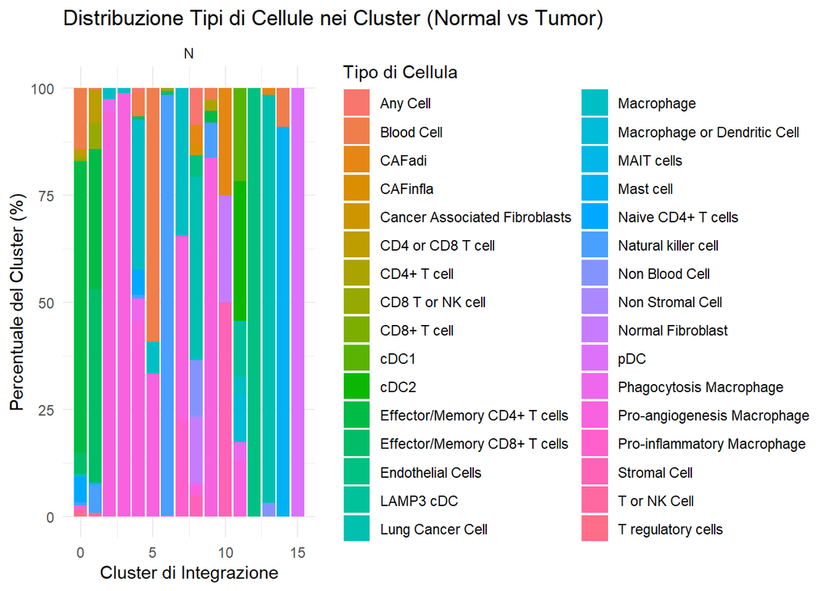

```r
master_clusters_dt <- fread("data/annotated_GSM3516673_normal_annotated_GSM3516672_tumor_SeuratIntegration.csv")
master_cell_types_dt <- fread("data/nt_combined_clustering.output.csv")

master_clusters_df <- as.data.frame(master_clusters_dt)
master_cell_types_df <- as.data.frame(master_cell_types_dt)

#Approcico con data.frame
time_df_final <- system.time({

  clusters_df <- master_clusters_df
  cell_types_df <- master_cell_types_df
  #pulizia
  clusters_df$cell <- gsub(pattern = "_X_\\.", replacement = ".", x = clusters_df$cell)

  # --- Task 1: Creare e salvare il file combinato ---
  merged_df_final <- merge(clusters_df, cell_types_df, by = "cell")

  write.csv(merged_df_final, "final_task1_combined_df.csv", row.names = FALSE)

  # --- Task 2: Creare e salvare il conteggio per cluster ---
  counts_df_final <- aggregate(cell ~ integration_cluster + cell_type,
                               data = merged_df_final,
                               FUN = length)
  colnames(counts_df_final)[3] <- "cell_count"

  write.csv(counts_df_final, "final_task2_counts_per_cluster_df.csv", row.names = FALSE)

  # --- Task 3: Creare e salvare la tabella riassuntiva N vs T ---
  summary_long_df <- aggregate(cell ~ integration_cluster + cell_type + sample_type,
                               data = merged_df_final,
                               FUN = length)
  colnames(summary_long_df)[4] <- "cell_count"

  summary_wide_df_final <- reshape(summary_long_df,
                                   idvar = c("integration_cluster", "cell_type"),
                                   timevar = "sample_type",
                                   direction = "wide")

  colnames(summary_wide_df_final) <- gsub("cell_count\\.", "", colnames(summary_wide_df_final))
  summary_wide_df_final[is.na(summary_wide_df_final)] <- 0

  write.csv(summary_wide_df_final, "final_task3_summary_N_vs_T_df.csv", row.names = FALSE)

  # --- Task 4: Calcolo Percentuale Normalizzata  ---

# totale cellule per gruppo
summary_long_df$group_total <- ave(summary_long_df$cell_count,
                                   summary_long_df$integration_cluster,
                                   summary_long_df$sample_type,
                                   FUN = sum)

summary_long_df$percentage <- (summary_long_df$cell_count / summary_long_df$group_total) * 100

print("Tabella con % Normalizzata (data.frame):")
head(summary_long_df, 5)

# --- Task 5: Creare il Plot  ---
final_plot_df <- ggplot(summary_long_df,
                        aes(x = integration_cluster, y = percentage, fill = cell_type)) +
  geom_bar(stat = "identity", position = "stack") +
  facet_wrap(~ sample_type) +
  labs(title = "Distribuzione Tipi di Cellule nei Cluster (Normal vs Tumor)",
       x = "Cluster di Integrazione",
       y = "Percentuale del Cluster (%)",
       fill = "Tipo di Cellula") +
  theme_minimal()  # Stile pulito

print(final_plot_df)
# Salviamo il grafico in un file
ggsave("final_plot_df.png", final_plot_df, width = 10, height = 6)

})
```

```r
print("--- Risultato con data.frame (Final Revision) ---")
```

```
## [1] "--- Risultato con data.frame (Final Revision) ---"
```

```r
head(merged_df_final, 5)
```

```
##                 cell integration_cluster                    cell_type
## 1 X120703408789411.N                   2  Pro-angiogenesis Macrophage
## 2 X120703408793835.N                   8               Non Blood Cell
## 3 X120703409145716.N                   0 Effector/Memory CD4+ T cells
## 4 X120703409339181.N                   1                   MAIT cells
## 5 X120703409379676.N                   3  Pro-angiogenesis Macrophage
##   sample_type
## 1           N
## 2           N
## 3           N
## 4           N
## 5           N
```

```r
print(time_df_final)
```

```
##    utente   sistema trascorso
##      0.86      0.08      1.15
```

```
## [1] "Tabella con % Normalizzata (data.table):"
```

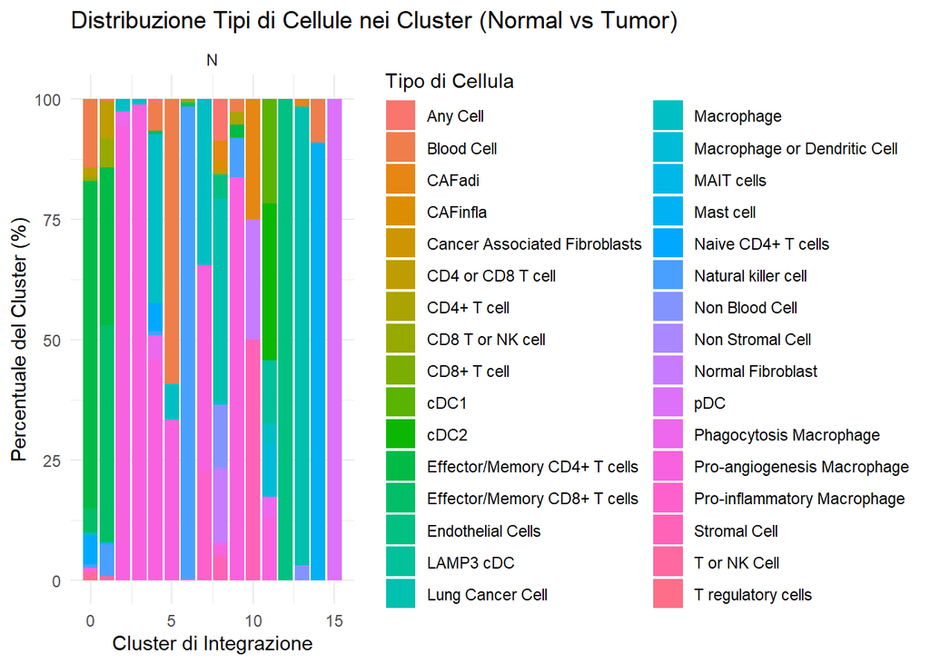

```r
#data.table
time_dt_final <- system.time({

  clusters_dt <- copy(master_clusters_dt)
  cell_types_dt <- copy(master_cell_types_dt)
  #Pulizia
  clusters_dt[, cell := gsub(pattern = "_X_\\.", replacement = ".", x = cell)]

  # --- Task 1: Creare e salvare il file combinato ---
  setkey(clusters_dt, cell)
  setkey(cell_types_dt, cell)
  merged_dt_final <- clusters_dt[cell_types_dt, nomatch = 0L]

  fwrite(merged_dt_final, "final_task1_combined_dt.csv")

  # --- Task 2: Creare e salvare il conteggio per cluster ---
  counts_dt_final <- merged_dt_final[, .(cell_count = .N),
                                     by = .(integration_cluster, cell_type)]

  fwrite(counts_dt_final, "final_task2_counts_per_cluster_dt.csv")

  # --- Task 3: Creare e salvare la tabella riassuntiva N vs T ---
  summary_wide_dt_final <- dcast(merged_dt_final,
                                 integration_cluster + cell_type ~ sample_type,
                                 fun.aggregate = length,       #calcola il conteggio
                                 value.var = "cell",
                                 fill = 0)     #riempie gli NA con 0

  fwrite(summary_wide_dt_final, "final_task3_summary_N_vs_T_dt.csv")


# --- Task 4 & 5  ---
summary_long_dt <- merged_dt_final[, .(cell_count = .N),
                                   by = .(integration_cluster, cell_type, sample_type)]
summary_long_dt[, percentage := (cell_count / sum(cell_count)) * 100,
                by = .(integration_cluster, sample_type)]

print("Tabella con % Normalizzata (data.table):")
head(summary_long_dt, 5)
final_plot_dt <- ggplot(summary_long_dt,
                        aes(x = integration_cluster, y = percentage, fill = cell_type)) + geom_bar(stat = "identity", position = "stack") +
  facet_wrap(~ sample_type) +
  labs(title = "Distribuzione Tipi di Cellule nei Cluster (Normal vs Tumor)",
       x = "Cluster di Integrazione",
       y = "Percentuale del Cluster (%)",
       fill = "Tipo di Cellula") +
  theme_minimal()

print(final_plot_dt)
ggsave("final_plot_dt.png", final_plot_dt, width = 10, height = 6)
})
```

```r
print("--- Risultato con data.table (Final Revision) ---")
```

```
## [1] "--- Risultato con data.table (Final Revision) ---"
```

```r
head(merged_dt_final, 5)
```

```
## Key: <cell>
##                  cell integration_cluster                    cell_type
##                <char>               <int>                       <char>
## 1: X120703408789411.N                   2  Pro-angiogenesis Macrophage
## 2: X120703408793835.N                   8               Non Blood Cell
## 3: X120703409145716.N                   0 Effector/Memory CD4+ T cells
## 4: X120703409339181.N                   1                   MAIT cells
## 5: X120703409379676.N                   3  Pro-angiogenesis Macrophage
##    sample_type
##         <char>
## 1:           N
## 2:           N
## 3:           N
## 4:           N
## 5:           N
```

```r
print(time_dt_final)
```

```
##    utente   sistema trascorso
##      0.64      0.04      1.00
```

— Final Performance Summary Table — This final chunk collects all the execution times and presents them in a comparison table.

Performance Comparison Table: data.frame vs data.table

| Task | Time_data_frame_sec | Time_data_table_sec | Speedup_data_table |
| --- | --- | --- | --- |
| 1. Filter/Group | 0.05 | 0.01 | 5.0000 |
| 2. Add QC Columns | 0.12 | 0.03 | 4.0000 |
| Ex 3.1: Join (Equi-join) | 0.01 | 0.00 | Inf |
| Ex 3.2: Search (Indexed) | 0.00 | 0.00 | NaN |
| Ex 4.1: Annotate (Patient Sum) | 0.05 | 0.02 | 2.5000 |
| Ex 4.2: Annotate (Top 10) | 0.05 | 0.02 | 2.5000 |
| 5. Classify Intervals | 0.00 | 0.00 | NaN |
| 7. Genomic Filter | 0.02 | 0.00 | Inf |
| 8. Multi-Column Stats | 0.44 | 0.30 | 1.4667 |
| 9. Wide -> Long -> Wide | 0.06 | 0.04 | 1.5000 |
| 10. Overlap Join (ATAC-Gene) | 3.12 | 0.02 | 156.0000 |
| 11. Overlap Join (SNP-Gene) | 0.76 | 0.05 | 15.2000 |
| 12. Combine Cohorts | 0.08 | 0.02 | 4.0000 |
| Final. Final Revision | 1.15 | 1.00 | 1.1500 |